# Part I - Loan Data Exploration

## Preliminary Wrangling

```python
# import all packages and set plots to be embedded inline
import numpy as np
import pandas as pd
import matplotlib.pyplot as plt
import matplotlib.ticker as mtick
import seaborn as sb

%matplotlib inline
```

```python
loans = pd.read_csv('prosperLoanData.csv')
```

```python
loans.head()
```

|  | ListingKey | ListingNumber | ListingCreationDate | CreditGrade | Term | LoanStatus | ClosedDate | BorrowerAPR | BorrowerRate | LenderYield | ... | LP_ServiceFees | LP_CollectionFees | LP_GrossPrincipalLoss | LP_NetPrincipalLoss | LP_NonPrincipalRecoverypayments | PercentFunded | Recommendations | InvestmentFromFriendsCount | InvestmentFromFriendsAmount | Investors |
| --- | --- | --- | --- | --- | --- | --- | --- | --- | --- | --- | --- | --- | --- | --- | --- | --- | --- | --- | --- | --- | --- |
| 0 | 1021339766868145413AB3B | 193129 | 2007-08-26 19:09:29.263000000 | C | 36 | Completed | 2009-08-14 00:00:00 | 0.16516 | 0.1580 | 0.1380 | ... | -133.18 | 0.0 | 0.0 | 0.0 | 0.0 | 1.0 | 0 | 0 | 0.0 | 258 |
| 1 | 10273602499503308B223C1 | 1209647 | 2014-02-27 08:28:07.900000000 | NaN | 36 | Current | NaN | 0.12016 | 0.0920 | 0.0820 | ... | 0.00 | 0.0 | 0.0 | 0.0 | 0.0 | 1.0 | 0 | 0 | 0.0 | 1 |
| 2 | 0EE9337825851032864889A | 81716 | 2007-01-05 15:00:47.090000000 | HR | 36 | Completed | 2009-12-17 00:00:00 | 0.28269 | 0.2750 | 0.2400 | ... | -24.20 | 0.0 | 0.0 | 0.0 | 0.0 | 1.0 | 0 | 0 | 0.0 | 41 |
| 3 | 0EF5356002482715299901A | 658116 | 2012-10-22 11:02:35.010000000 | NaN | 36 | Current | NaN | 0.12528 | 0.0974 | 0.0874 | ... | -108.01 | 0.0 | 0.0 | 0.0 | 0.0 | 1.0 | 0 | 0 | 0.0 | 158 |
| 4 | 0F023589499656230C5E3E2 | 909464 | 2013-09-14 18:38:39.097000000 | NaN | 36 | Current | NaN | 0.24614 | 0.2085 | 0.1985 | ... | -60.27 | 0.0 | 0.0 | 0.0 | 0.0 | 1.0 | 0 | 0 | 0.0 | 20 |

5 rows × 81 columns

### What is the structure of your dataset?

The listed category of each is assigned a value between 0 and 20. Credit grades are ranked using the Prosper Rating system ('AA', 'A', 'B', 'C', 'D', 'E', 'HR').

### What is/are the main feature(s) of interest in your dataset?

I'm interested in seeing what characteristics make a loan risky and safe.

### What features in the dataset do you think will help support your investigation into your feature(s) of interest?

I think BorrowerAPR, Current Delinquencies, Credit score range, and debt to income ratio will help determine the risk level of a loan. I expect that the lower the debt to income ratio is, the safer the loan.

## Univariate Exploration

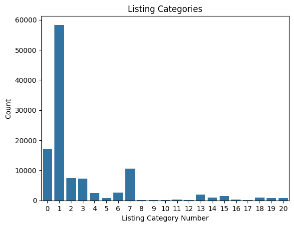

```python
def labels(xlabel, ylabel, title):
    plt.xlabel(xlabel)
    plt.ylabel(ylabel)
    plt.title(title)

listing_category_bins = np.arange(0, 21, 1)

color = sb.color_palette()[0]
sb.countplot(data=loans, x='ListingCategory (numeric)', color=color)
labels('Listing Category Number', 'Count', 'Listing Categories')
plt.xticks(ticks=listing_category_bins);
```

This is the list of the numeric values assigned to each loan

- 0 - Not Available
- 1 - Debt Consolidation
- 2 - Home Improvement
- 3 - Business
- 4 - Personal Loan
- 5 - Student Use
- 6 - Auto
- 7- Other
- 8 - Baby&Adoption
- 9 - Boat
- 10 - Cosmetic Procedure
- 11 - Engagement Ring
- 12 - Green Loans
- 13 - Household Expenses
- 14 - Large Purchases
- 15 - Medical/Dental
- 16 - Motorcycle
- 17 - RV
- 18 - Taxes
- 19 - Vacation
- 20 - Wedding Loans

A vast majority of the loans are for Debt Consolidation. The second most were "Not Available," and the third most were labeled "Other."

```python
loans.DebtToIncomeRatio.describe()
```

```
count    105383.000000
mean          0.275947
std           0.551759
min           0.000000
25%           0.140000
50%           0.220000
75%           0.320000
max          10.010000
Name: DebtToIncomeRatio, dtype: float64
```

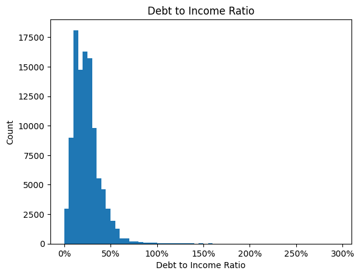

```python
debt_to_income_bins = np.arange(0, 3, 0.05)
plt.hist(loans['DebtToIncomeRatio'], bins=debt_to_income_bins)
plt.gca().xaxis.set_major_formatter(mtick.PercentFormatter(1.0, decimals=0))
labels('Debt to Income Ratio', 'Count', 'Debt to Income Ratio');
```

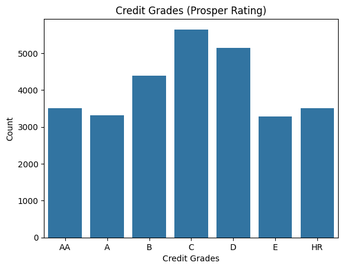

```python
creditgrade_order = ['AA', 'A', 'B', 'C', 'D', 'E', 'HR']
sb.countplot(data= loans, x= 'CreditGrade', color= color, order= creditgrade_order)
labels('Credit Grades', 'Count', 'Credit Grades (Prosper Rating)');
```

```python
loans['CreditGrade'].value_counts()
```

```
C     5649
D     5153
B     4389
AA    3509
HR    3508
A     3315
E     3289
NC     141
Name: CreditGrade, dtype: int64
```

The bars are sorted by credit grades (AA being the loan is safe and HR being the loan is risky). I am surprised that most loans were graded as C. I expected a majority to have an A or B rating.

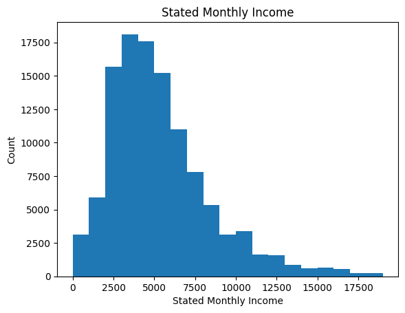

```python
monthly_income_bins = np.arange(0, 20000, 1000)
plt.hist(loans['StatedMonthlyIncome'], bins= monthly_income_bins)
labels('Stated Monthly Income', 'Count', 'Stated Monthly Income');
```

```python
loans.StatedMonthlyIncome.describe()
```

```
count    1.139370e+05
mean     5.608026e+03
std      7.478497e+03
min      0.000000e+00
25%      3.200333e+03
50%      4.666667e+03
75%      6.825000e+03
max      1.750003e+06
Name: StatedMonthlyIncome, dtype: float64
```

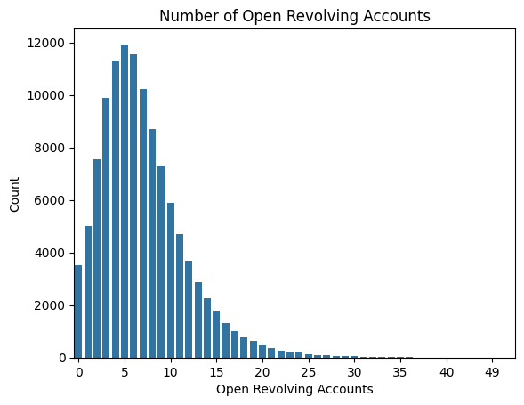

```python
open_revolving_account_bins = np.arange(0, 50, 5)
sb.countplot(x=loans['OpenRevolvingAccounts'], color=color)
plt.xticks(ticks= open_revolving_account_bins)
labels('Open Revolving Accounts', 'Count', 'Number of Open Revolving Accounts');
```

```python
loans.OpenRevolvingAccounts.describe()
```

```
count    113937.00000
mean          6.96979
std           4.63097
min           0.00000
25%           4.00000
50%           6.00000
75%           9.00000
max          51.00000
Name: OpenRevolvingAccounts, dtype: float64
```

This graph shows a similar skew to the histogram for stated monthly income. I was expecting the mean to be lower than 7.

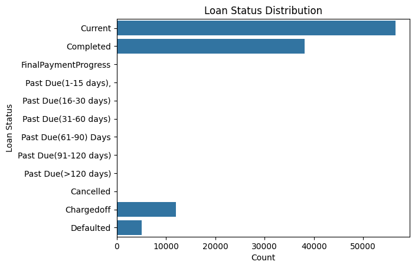

```python
loanstatus_order = ['Current', 'Completed', 'FinalPaymentProgress', 'Past Due(1-15 days),',
                    'Past Due(16-30 days)', 'Past Due(31-60 days)', 'Past Due(61-90) Days',
                    'Past Due(91-120 days)', 'Past Due(>120 days)', 'Cancelled', 'Chargedoff',
                    'Defaulted']
sb.countplot(data=loans, y='LoanStatus', color=color, order=loanstatus_order)
labels('Count', 'Loan Status', 'Loan Status Distribution');
```

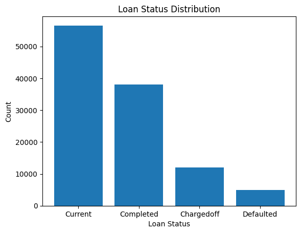

```python
loanstatus_order = loans.LoanStatus.value_counts().index
desired_statuses = ["Current", "Completed", "Chargedoff", "Defaulted"]
filtered_loans = loans[loans["LoanStatus"].isin(desired_statuses)]

status_counts = filtered_loans["LoanStatus"].value_counts()

plt.bar(status_counts.index, status_counts.values, color=color)
labels('Loan Status', 'Count', 'Loan Status Distribution')
plt.show();
```

```python
filtered_loans.shape[0] / filtered_loans[filtered_loans['LoanStatus'] == 'Chargedoff'].shape[0]
```

```
9.311207471647766
```

### Discuss the distribution(s) of your variable(s) of interest. Were there any unusual points? Did you need to perform any transformations?

Most loans were for Debt Consolidation and had a right skew distribution. Debt to income ratio showed a right skew. Stated monthly income and Open Revolving Accounts also had a right skew. In the Loan Status bar chart, all loans with past due status, finalpaymentinprogress, and canceled status were tiny. Yes, I performed a transformation on the loan status and debt to income ratio variables.

### Of the features you investigated, were there any unusual distributions? Did you perform any operations on the data to tidy, adjust, or change the form of the data? If so, why did you do this?

Loan status had the most unusual distribution. I did the transformations because both variables had many outliers, so removing them would make the chart look better and accurately represent the data.

## Bivariate Exploration

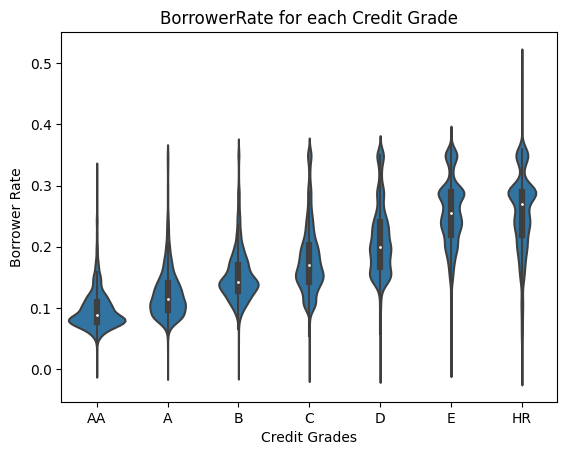

```python
sb.violinplot(data=loans, x=loans['CreditGrade'], y=loans['BorrowerRate'], color=color, order= creditgrade_order)
labels('Credit Grades', 'Borrower Rate', 'BorrowerRate for each Credit Grade');
```

I notice that the riskier the loan, the more variation spread out the borrower rate is.

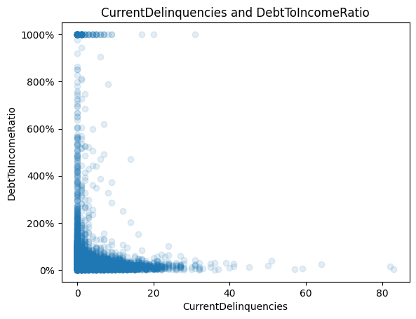

```python
sb.regplot(data=loans, x='CurrentDelinquencies', y='DebtToIncomeRatio', scatter_kws={'alpha':1/8}, fit_reg=False)
plt.gca().yaxis.set_major_formatter(mtick.PercentFormatter(1.0, decimals=0))
labels('CurrentDelinquencies', 'DebtToIncomeRatio', 'CurrentDelinquencies and DebtToIncomeRatio');
```

Most of the data is clustered in the bottom left corner, which tells me that most loans have a low debt to income ratio and low Current Delinquencies.

[figure not shown]

```python
sb.boxplot(data=loans, x='CreditGrade', y='CreditScoreRangeLower', color=color ,order=creditgrade_order)
labels('Credit Grade', 'Credit Score Range (Upper)', 'Credit Score Range (Upper) per Credit Grade');
```

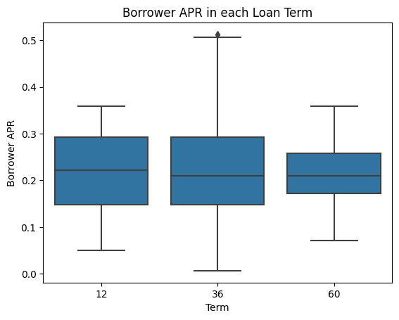

```python
sb.boxplot(data=loans, x='Term', y='BorrowerAPR', color=color)
labels('Term', 'Borrower APR', 'Borrower APR in each Loan Term');
```

```python
loans.Term.value_counts()
```

```
36    87778
60    24545
12     1614
Name: Term, dtype: int64
```

The loans that were 12 to 36 months have identical first and third-quartile ranges. Most loans were 36 months, followed by 60 and then 12.

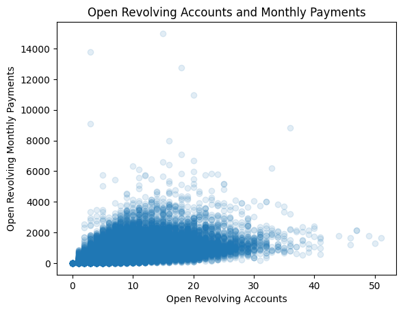

```python
sb.regplot(data=loans, x='OpenRevolvingAccounts', y='OpenRevolvingMonthlyPayment', scatter_kws={'alpha':1/8}, fit_reg=False)
labels('Open Revolving Accounts', 'Open Revolving Monthly Payments', 'Open Revolving Accounts and Monthly Payments');
```

```python
loans['OpenRevolvingAccounts'].corr(loans['OpenRevolvingMonthlyPayment'])
```

```
0.5853797974561302
```

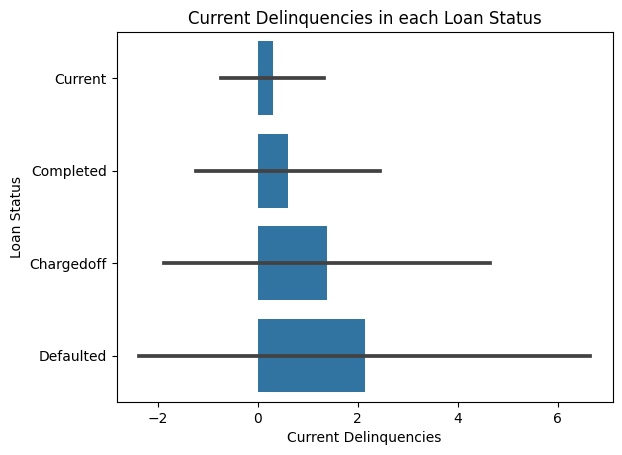

```python
sb.barplot(data=filtered_loans, x='CurrentDelinquencies', y='LoanStatus', color=color, order=desired_statuses, errorbar='sd')
labels('Current Delinquencies', 'Loan Status', 'Current Delinquencies in each Loan Status');
```

The error bar I chose for this bar plot is the standard deviation. Defaulted loans have the highest average current delinquencies, with about 2. Loans with Chargedoff and Defaulted status have higher averages and standard deviations than loans with current and completed loan status.

## Multivariate Exploration

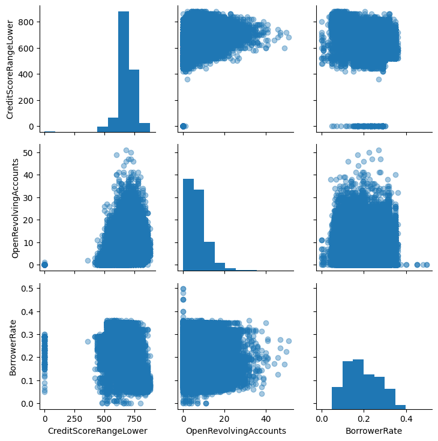

```python
loan_variables = ['CreditScoreRangeLower', 'OpenRevolvingAccounts', 'BorrowerRate']
g = sb.PairGrid(data = loans, vars = loan_variables)
g.map_diag(plt.hist)
g.map_offdiag(plt.scatter, alpha=0.4);
```

It seems that there is some positive correlation when plotting CreditScoreRangeLower and OpenRevolvingAccounts (Middle left graph)

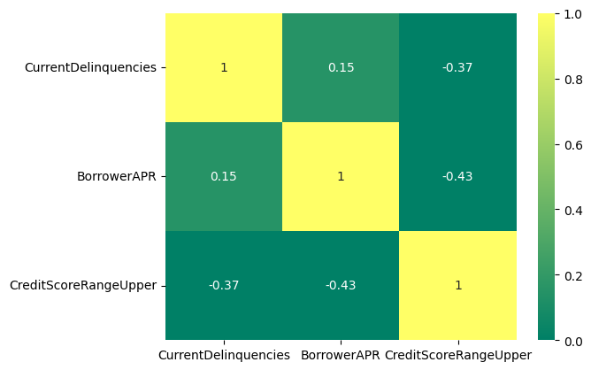

```python
loan_variables1 = ['CurrentDelinquencies', 'BorrowerAPR', 'CreditScoreRangeUpper']
sb.heatmap(loans[loan_variables1].corr(), cmap='summer',annot= True, vmin= 0);
```

BorrowerAPR and CurrentDelinquencies show a slight positive correlation of 0.15. BorrowerAPR and CreditScoreRangeUpper have the most negative correlation with -0.43, which is surprising.

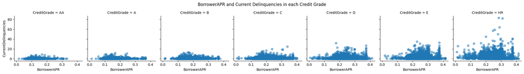

```python
loan_variables2 = ['CreditGrade', 'BorrowerAPR', 'CurrentDelinquencies']
i = sb.FacetGrid(data = loans, col='CreditGrade', col_order= creditgrade_order, )
i.map(plt.scatter, 'BorrowerAPR', 'CurrentDelinquencies', alpha= 0.5)
i.fig.suptitle('BorrowerAPR and Current Delinquencies in each Credit Grade')
i.fig.subplots_adjust(top=0.8);
```

As the credit grade lowers, the number of loans with a high amount of current delinquencies increases.

### Talk about some of the relationships you observed in this part of the investigation. Were there features that strengthened each other in terms of looking at your feature(s) of interest?

Seeing loans with a risker grade have more current delinquencies and BorrowerAPR helped reinforce my feature of interest.

### Were there any interesting or surprising interactions between features?

I was surprised that there was a negative correlation between BorrowerAPR and CreditScoreRangeUpper.